# Mantel test Galapagos - Floristic & Currents conectivity

In this script, we will convert the obtained floristic and currents matrices (floristic dissimilatiry matrix and oceanic current connectivity matrix) into distance matrices and perform a Procrustes analyses to explore their correlation and answer whether highly sea-current-connected islands more floristicaly similar.

We will also analyze whether floristic similarities are related to geographic, area, and age distance between islands.

```r
library(ade4)
library(qgraph)
library(ecodist)
library(vegan)
library(tidyverse)
library(cluster)
library(textshape)
library(dplyr)
library(tidyverse)
library(cluster)
library(spaa)

source("../Script/Functions.R")
```

### Load data

#### Load floristic matrices and convert to distance objects

```r
# All species
distflor_all_gal<-load_order_convert_table_to_distanceMat(
  filepath="Dist_Matices_floras_Galapagos/df_all_gal")

distflor_all_can<-load_order_convert_table_to_distanceMat(
  filepath="Dist_Matices_floras_Canaries/df_all_can")

distflor_all_az<-load_order_convert_table_to_distanceMat(
  filepath="Dist_Matices_floras_Azores/df_all_az")


# Thalassocorous

distflor_tha_gal<-load_order_convert_table_to_distanceMat(
  filepath="Dist_Matices_floras_Galapagos/df_thalassochory_gal")

distflor_tha_can<-load_order_convert_table_to_distanceMat(
  filepath="Dist_Matices_floras_Canaries/df_thalassochory_can")

distflor_tha_az<-load_order_convert_table_to_distanceMat(
  filepath="Dist_Matices_floras_Azores/df_thalassochory_az")


# Fleshy fruited

distflor_freshy_gal<-load_order_convert_table_to_distanceMat(
  filepath="Dist_Matices_floras_Galapagos/df_fleshy_fruits_gal")


# Littoral

distflor_litt_gal<-load_order_convert_table_to_distanceMat(
  filepath="Dist_Matices_floras_Galapagos/df_littoral_gal")

distflor_litt_can<-load_order_convert_table_to_distanceMat(
  filepath="Dist_Matices_floras_Canaries/df_littoral_can")

distflor_litt_az<-load_order_convert_table_to_distanceMat(
  filepath="Dist_Matices_floras_Azores/df_littoral_az")



# Littoral exclusive

distflor_litt.excl_gal<-load_order_convert_table_to_distanceMat(
  filepath="Dist_Matices_floras_Galapagos/df_littoral_exclusive_gal")

distflor_litt.excl_can<-load_order_convert_table_to_distanceMat(
  filepath="Dist_Matices_floras_Canaries/df_littoral_exclusive_can")

distflor_litt.excl_az<-load_order_convert_table_to_distanceMat(
  filepath="Dist_Matices_floras_Azores/df_littoral_exclusive_az")



# All but thalassochorous

distflor_no.tha_gal<-load_order_convert_table_to_distanceMat(
  filepath="Dist_Matices_floras_Galapagos/df_all_without_thalassochory_gal")

distflor_no.tha_can<-load_order_convert_table_to_distanceMat(
  filepath="Dist_Matices_floras_Canaries/df_all_without_thalassochory_can")

distflor_no.tha_az<-load_order_convert_table_to_distanceMat(
  filepath="Dist_Matices_floras_Azores/df_all_without_thalassochory_az")




# All but littoral

distflor_no.litt_gal<-load_order_convert_table_to_distanceMat(
  filepath="Dist_Matices_floras_Galapagos/df_all_without_littoral_gal")

distflor_no.litt_can<-load_order_convert_table_to_distanceMat(
  filepath="Dist_Matices_floras_Canaries/df_all_without_littoral_can")

distflor_no.litt_az<-load_order_convert_table_to_distanceMat(
  filepath="Dist_Matices_floras_Azores/df_all_without_littoral_az")



# All but littoral exlusive

distflor_no.littexcl_gal<-load_order_convert_table_to_distanceMat(
  filepath="Dist_Matices_floras_Galapagos/df_all_without_littoral_exclusive_gal")

distflor_no.littexcl_can<-load_order_convert_table_to_distanceMat(
  filepath="Dist_Matices_floras_Canaries/df_all_without_littoral_exclusive_can")

distflor_no.littexcl_az<-load_order_convert_table_to_distanceMat(
  filepath="Dist_Matices_floras_Azores/df_all_without_littoral_exclusive_az")



 # All but fleshy fruited

distflor_no.fleshy_gal<-load_order_convert_table_to_distanceMat(
  filepath="Dist_Matices_floras_Galapagos/df_all_without_fleshy_gal")
```

#### Load currents and geographic matrices and convert to distance objects

```r
# Currents distance matrix

dist_curr_gal<-load_order_convert_csv_to_distanceMat(filepath ="../Matrices/Galapagos/Matrices-Currents_Galap/matrix_median_min_final_Galapagos.csv")

dist_curr_can<-load_order_convert_csv_to_distanceMat(filepath ="../Matrices/Canaries/Matrices-Currents_Canaries/matrix_median_min_final_Canaries.csv")

dist_curr_az<-load_order_convert_csv_to_distanceMat(filepath ="../Matrices/Azores/Matrices-Currents_Azores/matrix_median_min_final_Azores.csv")



dist_curr_gal<-load_order_convert_csv_to_distanceMat(filepath ="../Matrices/Galapagos/Matrices-Currents_Galap/matrix_median_min_final_Galapagos.csv")

# Geographic distance matrix


dist_geo_gal<-load_order_convert_csv_to_distanceMat(filepath ="../Matrices/Galapagos/Matrices-Geographic_Galap/geographic_distance_galap.csv")

dist_geo_can<-load_order_convert_csv_to_distanceMat(filepath ="../Matrices/Canaries/Matrices-Geographic_Canaries/geographic_distance_canaries.csv")

dist_geo_az<-load_order_convert_csv_to_distanceMat(filepath ="../Matrices/Azores/Matrices-Geographic_Azores/geographic_distance_azores.csv")
```

#### Load island area matrices and convert to distance objects

Here we first open the file to calculate euclidean distances, and save it with write.table function to make it as we want

```r
df_area<-read.csv("../Data/Data_Galapagos/area_islands_galap.csv")
df_area1<-column_to_rownames(df_area, 'X')

dist_area<-daisy(df_area1, metric="euclidean")

write.table(as.matrix(dist_area), file = "../Data/Data_Galapagos/Area_islands_Galapagos",
            append = FALSE, quote = TRUE, sep = " ",
            eol = "\n", na = "NA", dec = ".", row.names = TRUE,
            col.names = TRUE, qmethod = c("escape", "double"),
            fileEncoding = "")

Area_islands_gal<-read.table("../Data/Data_Galapagos/Area_islands_Galapagos")




df_area<-read.csv("../Data/Data_Canaries/area_islands_canaries.csv")
df_area1<-column_to_rownames(df_area, 'X')

dist_area<-daisy(df_area1, metric="euclidean")

write.table(as.matrix(dist_area), file = "../Data/Data_Canaries/Area_islands_Canaries",
            append = FALSE, quote = TRUE, sep = " ",
            eol = "\n", na = "NA", dec = ".", row.names = TRUE,
            col.names = TRUE, qmethod = c("escape", "double"),
            fileEncoding = "")

Area_islands_can<-read.table("../Data/Data_Canaries/Area_islands_Canaries")





df_area<-read.csv("../Data/Data_Azores/area_islands_azores.csv")
df_area1<-column_to_rownames(df_area, 'X')

dist_area<-daisy(df_area1, metric="euclidean")

write.table(as.matrix(dist_area), file = "../Data/Data_Azores/Area_islands_Azores",
            append = FALSE, quote = TRUE, sep = " ",
            eol = "\n", na = "NA", dec = ".", row.names = TRUE,
            col.names = TRUE, qmethod = c("escape", "double"),
            fileEncoding = "")

Area_islands_az<-read.table("../Data/Data_Azores/Area_islands_Azores")
```

```r
dist_area_gal<-load_order_convert_table_to_distanceMat(filepath = "../Data/Data_Galapagos/Area_islands_Galapagos")

dist_area_can<-load_order_convert_table_to_distanceMat(filepath = "../Data/Data_Canaries/Area_islands_Canaries")

dist_area_az<-load_order_convert_table_to_distanceMat(filepath = "../Data/Data_Azores/Area_islands_Azores")
```

#### Load island age matrices and convert to distance objects

```r
df_Ages<-read.csv("../Data/Data_Galapagos/df_ages_Galap.csv", sep=";")
df_Ages1<-column_to_rownames(df_Ages, 'island')

dist_Ages<-daisy(df_Ages1, metric="euclidean")

write.table(as.matrix(dist_Ages), file = "../Data/Data_Galapagos/Ages_islands_Galapagos",
            append = FALSE, quote = TRUE, sep = " ",
            eol = "\n", na = "NA", dec = ".", row.names = TRUE,
            col.names = TRUE, qmethod = c("escape", "double"),
            fileEncoding = "")


Ages_islands_gal<-read.table("../Data/Data_Galapagos/Ages_islands_Galapagos")




df_Ages<-read.csv("../Data/Data_Canaries/df_ages_canaries.csv", sep=";")
df_Ages1<-column_to_rownames(df_Ages, 'island')

dist_Ages<-daisy(df_Ages1, metric="euclidean")

write.table(as.matrix(dist_Ages), file = "../Data/Data_Canaries/Ages_islands_Canaries",
            append = FALSE, quote = TRUE, sep = " ",
            eol = "\n", na = "NA", dec = ".", row.names = TRUE,
            col.names = TRUE, qmethod = c("escape", "double"),
            fileEncoding = "")


Ages_islands_can<-read.table("../Data/Data_Canaries/Ages_islands_Canaries")




df_Ages<-read.csv("../Data/Data_Azores/df_ages_azores.csv", sep=";")
df_Ages1<-column_to_rownames(df_Ages, 'island')

dist_Ages<-daisy(df_Ages1, metric="euclidean")

write.table(as.matrix(dist_Ages), file = "../Data/Data_Azores/Ages_islands_Azores",
            append = FALSE, quote = TRUE, sep = " ",
            eol = "\n", na = "NA", dec = ".", row.names = TRUE,
            col.names = TRUE, qmethod = c("escape", "double"),
            fileEncoding = "")


Ages_islands_az<-read.table("../Data/Data_Azores/Ages_islands_Azores")
```

```r
dist_age_gal<-load_order_convert_table_to_distanceMat(filepath = "../Data/Data_Galapagos/Ages_islands_Galapagos")

dist_age_can<-load_order_convert_table_to_distanceMat(filepath = "../Data/Data_Canaries/Ages_islands_Canaries")

dist_age_az<-load_order_convert_table_to_distanceMat(filepath = "../Data/Data_Azores/Ages_islands_Azores")
```

# Procrustes test

## Floras - currents

```r
# All species

protest_curr_FlorAll_gal <-Compute_Protest_distMat(distMat_rot=distflor_all_gal,distMat_base = dist_curr_gal,k=11)
protest_curr_FlorAll_can <-Compute_Protest_distMat(distMat_rot=distflor_all_can,distMat_base = dist_curr_can, k=6)
protest_curr_FlorAll_az <-Compute_Protest_distMat(distMat_rot=distflor_all_az,distMat_base = dist_curr_az,k=8)


# Non-adapted

protest_curr_Flornonad_gal <-Compute_Protest_distMat(distMat_rot=distflor_nonad_gal,distMat_base = dist_curr_gal,k=11)
protest_curr_Flornonad_can <-Compute_Protest_distMat(distMat_rot=distflor_nonad_can,distMat_base = dist_curr_can, k=6)
protest_curr_Flornonad_az <-Compute_Protest_distMat(distMat_rot=distflor_nonad_az,distMat_base = dist_curr_az,k=8)

# Thalassochorous

protest_curr_Flortha_gal <-Compute_Protest_distMat(distMat_rot=distflor_tha_gal,distMat_base = dist_curr_gal,k=11)
protest_curr_Flortha_can <-Compute_Protest_distMat(distMat_rot=distflor_tha_can,distMat_base = dist_curr_can, k=6)
protest_curr_Flortha_az <-Compute_Protest_distMat(distMat_rot=distflor_tha_az,distMat_base = dist_curr_az,k=8)


# Littoral

protest_curr_FlorLitt_gal <-Compute_Protest_distMat(distMat_rot=distflor_litt_gal,distMat_base = dist_curr_gal,k=11)
protest_curr_FlorLitt_can <-Compute_Protest_distMat(distMat_rot=distflor_litt_can,distMat_base = dist_curr_can, k=6)
protest_curr_FlorLitt_az <-Compute_Protest_distMat(distMat_rot=distflor_litt_az,distMat_base = dist_curr_az,k=8)


# Littoral exclusive

protest_curr_FlorLitt.excl_gal <-Compute_Protest_distMat(distMat_rot=distflor_litt.excl_gal,distMat_base = dist_curr_gal,k=11)
protest_curr_FlorLitt.excl_can <-Compute_Protest_distMat(distMat_rot=distflor_litt.excl_can,distMat_base = dist_curr_can, k=6)
protest_curr_FlorLitt.excl_az <-Compute_Protest_distMat(distMat_rot=distflor_litt.excl_az,distMat_base = dist_curr_az,k=8)


# Fleshy fruitted

protest_curr_Florflesh_gal <-Compute_Protest_distMat(distMat_rot=distflor_freshy_gal,distMat_base = dist_curr_gal,k=11)



# All but thalassochorous

protest_curr_FlorNotha.excl_gal <-Compute_Protest_distMat(distMat_rot=distflor_no.tha_gal,distMat_base = dist_curr_gal,k=11)
protest_curr_FlorNotha.excl_can <-Compute_Protest_distMat(distMat_rot=distflor_no.tha_can,distMat_base = dist_curr_can, k=6)
protest_curr_FlorNotha.excl_az <-Compute_Protest_distMat(distMat_rot=distflor_no.tha_az,distMat_base = dist_curr_az,k=8)


# All but Littoral


protest_curr_FlorNoLitt.excl_gal <-Compute_Protest_distMat(distMat_rot=distflor_no.litt_gal,distMat_base = dist_curr_gal,k=11)
protest_curr_FlorNoLitt.excl_can <-Compute_Protest_distMat(distMat_rot=distflor_no.litt_can,distMat_base = dist_curr_can, k=6)
protest_curr_FlorNoLitt.excl_az <-Compute_Protest_distMat(distMat_rot=distflor_no.litt_az,distMat_base = dist_curr_az,k=8)


# All but Littoral exclusive

protest_curr_FlorNoLitt.excl_gal <-Compute_Protest_distMat(distMat_rot=distflor_no.littexcl_gal,distMat_base = dist_curr_gal,k=11)
protest_curr_FlorNoLitt.excl_can <-Compute_Protest_distMat(distMat_rot=distflor_no.littexcl_can,distMat_base = dist_curr_can, k=6)
protest_curr_FlorNoLitt.excl_az <-Compute_Protest_distMat(distMat_rot=distflor_no.littexcl_az,distMat_base = dist_curr_az,k=8)
```

### Plot the results

This chunk saves procrustes tests in the local repository file “plots”. It can be ignored for the analyses.

Plots are Kind 1, which gives a visual indication of the degree of match between the two ordinations. Symbols or labels show the position of the samples in the first ordination, and arrows point to their positions in the target ordination. The plot also shows the rotation between the two ordinations necessary to make them match as closely as possible

```r
# All

pdf(file= "plots/procrustes/protest_curr_FlorAll_gal.pdf" )
plot(protest_curr_FlorAll_gal, kind=1, type = "text",cex = 1.2, main = "Currents & All plants", ar.col = "red1", len = 0.2)

pdf(file= "plots/procrustes/protest_curr_FlorAll_can.pdf" )
plot(protest_curr_FlorAll_can,kind=1, type = "text",cex = 1.2,main = "Currents & All plants", ar.col = "red1", len = 0.2)

pdf(file= "plots/procrustes/protest_curr_FlorAll_az.pdf" )
plot(protest_curr_FlorAll_az,kind=1, type = "text",cex = 1.2,main = "Currents & All plants", ar.col = "red1", len = 0.2)




# Thalassochorous

pdf(file= "plots/procrustes/protest_curr_Flortha_gal.pdf" )
plot(protest_curr_Flortha_gal, kind=1, type = "text",cex = 1.2, main = "Currents & Thalassochorous plants", ar.col = "red1", len = 0.2)

pdf(file= "plots/procrustes/protest_curr_Flortha_can.pdf" )
plot(protest_curr_Flortha_can,kind=1, type = "text",cex = 1.2,main = "Currents & Thalassochorous plants", ar.col = "red1", len = 0.2)

pdf(file= "plots/procrustes/protest_curr_Flortha_az.pdf" )
plot(protest_curr_Flortha_az,kind=1, type = "text",cex = 1.2, main = "Currents & Thalassochorous plants", ar.col = "red1", len = 0.2)


# Littoral

pdf(file= "plots/procrustes/protest_curr_FlorLitt_gal.pdf" )
plot(protest_curr_FlorLitt_gal, kind=1, type = "text",cex = 1.2, main = "Currents & Littoral plants", ar.col = "red1", len = 0.2)

pdf(file= "plots/procrustes/protest_curr_FlorLitt_can.pdf" )
plot(protest_curr_FlorLitt_can,kind=1, type = "text",cex = 1.2,main = "Currents & Littoral plants", ar.col = "red1", len = 0.2)

pdf(file= "plots/procrustes/protest_curr_FlorLitt_az.pdf" )
plot(protest_curr_FlorLitt_az,kind=1, type = "text",cex = 1.2,main = "Currents & Littoral plants", ar.col = "red1", len = 0.2)


# Littoral exclusive

pdf(file= "plots/procrustes/protest_curr_FlorLitt.excl_gal.pdf" )
plot(protest_curr_FlorLitt.excl_gal, kind=1, type = "text",cex = 1.2, main = "Currents & Littoral exclusive plants", ar.col = "red1", len = 0.2)

pdf(file= "plots/procrustes/protest_curr_FlorLitt.excl_can.pdf" )
plot(protest_curr_FlorLitt.excl_can,kind=1, type = "text",cex = 1.2,main = "Currents & Littoral exclusive plants", ar.col = "red1", len = 0.2)

pdf(file= "plots/procrustes/protest_curr_FlorLitt.excl_az.pdf" )
plot(protest_curr_FlorLitt.excl_az,kind=1, type = "text",cex = 1.2,main = "Currents & Littoral exclusive plants", ar.col = "red1", len = 0.2)


# Fleshy fruited

pdf(file= "plots/procrustes/protest_curr_Florflesh_gal.pdf" )
plot(protest_curr_Florflesh_gal, kind=1, type = "text",cex = 1.2, main = "Currents & Fleshy fruited plants", ar.col = "red1", len = 0.2)
```

Plots

```r
par(mfrow=c(2,3))

plot(protest_curr_Flortha_gal, kind=1, type = "text",cex = 1.2, main = "Currents & Thalassochorous plants", ar.col = "red1", len = 0.2)
plot(protest_curr_Flortha_gal, kind=1, type = "text",cex = 1.2, main = "Currents & Thalassochorous plants", ar.col = "red1", len = 0.2)
```

```r
plot(protest_curr_FlorLitt_gal, kind=1, type = "text",cex = 1.2, main = "Currents & Littoral plants", ar.col = "red1", len = 0.2)
plot(protest_curr_FlorLitt.excl_gal, kind=1, type = "text",cex = 1.2, main = "Currents & Littoral exclusive plants", ar.col = "red1", len = 0.2)
```

[figure not shown]

```r
plot(protest_curr_Florflesh_gal, kind=1, type = "text",cex = 1.2, main = "Currents & Fleshy fruited plants", ar.col = "red1", len = 0.2)
```

```r
par(mfrow=c(2,2))


plot(protest_curr_FlorAll_can,kind=1, type = "text",cex = 1.2,main = "Currents & All plants", ar.col = "red1", len = 0.2)
plot(protest_curr_Flortha_can,kind=1, type = "text",cex = 1.2,main = "Currents & Thalassochorous plants", ar.col = "red1", len = 0.2)
plot(protest_curr_FlorLitt_can,kind=1, type = "text",cex = 1.2,main = "Currents & Littoral plants", ar.col = "red1", len = 0.2)
plot(protest_curr_FlorLitt.excl_az,kind=1, type = "text",cex = 1.2,main = "Currents & Littoral exclusive plants", ar.col = "red1", len = 0.2)
```

```r
par(mfrow=c(2,2))


plot(protest_curr_FlorAll_az,kind=1, type = "text",cex = 1.2,main = "Currents & All plants", ar.col = "red1", len = 0.2)
plot(protest_curr_Flortha_az,kind=1, type = "text",cex = 1.2, main = "Currents & Thalassochorous plants", ar.col = "red1", len = 0.2)
plot(protest_curr_FlorLitt_az,kind=1, type = "text",cex = 1.2,main = "Currents & Littoral plants", ar.col = "red1", len = 0.2)
plot(protest_curr_FlorLitt.excl_az,kind=1, type = "text",cex = 1.2,main = "Currents & Littoral exclusive plants", ar.col = "red1", len = 0.2)
```

## Floras - geo

```r
protest_geo_FlorAll_gal <-Compute_Protest_distMat(distMat_rot=distflor_all_gal,distMat_base = dist_geo_gal,k=11)
```

```
species scores not available
species scores not available
```

```r
protest_geo_FlorAll_can <-Compute_Protest_distMat(distMat_rot=distflor_all_can,distMat_base = dist_geo_can, k=6)
```

```
species scores not available
species scores not available
```

```
'nperm' >= set of all permutations: complete enumeration.
Set of permutations < 'minperm'. Generating entire set.
```

```r
protest_geo_FlorAll_az <-Compute_Protest_distMat(distMat_rot=distflor_all_az,distMat_base = dist_geo_az,k=8)
```

```
species scores not available
species scores not available
```

```r
# Non-adapted

protest_geo_Flornonad_gal <-Compute_Protest_distMat(distMat_rot=distflor_nonad_gal,distMat_base = dist_geo_gal,k=11)
```

```
species scores not available
species scores not available
```

```r
protest_geo_Flornonad_can <-Compute_Protest_distMat(distMat_rot=distflor_nonad_can,distMat_base = dist_geo_can, k=6)
```

```
species scores not available
species scores not available
```

```
'nperm' >= set of all permutations: complete enumeration.
Set of permutations < 'minperm'. Generating entire set.
```

```r
protest_geo_Flornonad_az <-Compute_Protest_distMat(distMat_rot=distflor_nonad_az,distMat_base = dist_geo_az,k=8)
```

```
species scores not available
species scores not available
```

```r
# Thalassochorous

protest_geo_Flortha_gal <-Compute_Protest_distMat(distMat_rot=distflor_all_gal,distMat_base = dist_geo_gal,k=11)
```

```
species scores not available
species scores not available
```

```r
protest_geo_Flortha_can <-Compute_Protest_distMat(distMat_rot=distflor_tha_can,distMat_base = dist_geo_can, k=6)
```

```
species scores not available
species scores not available
```

```
'nperm' >= set of all permutations: complete enumeration.
Set of permutations < 'minperm'. Generating entire set.
```

```r
protest_geo_Flortha_az <-Compute_Protest_distMat(distMat_rot=distflor_tha_az,distMat_base = dist_geo_az,k=8)
```

```
species scores not available
species scores not available
```

```r
# Littoral

protest_geo_FlorLitt_gal <-Compute_Protest_distMat(distMat_rot=distflor_litt_gal,distMat_base = dist_geo_gal,k=11)
```

```
species scores not available
species scores not available
```

```r
protest_geo_FlorLitt_can <-Compute_Protest_distMat(distMat_rot=distflor_litt_can,distMat_base = dist_geo_can, k=6)
```

```
species scores not available
species scores not available
```

```
'nperm' >= set of all permutations: complete enumeration.
Set of permutations < 'minperm'. Generating entire set.
```

```r
protest_geo_FlorLitt_az <-Compute_Protest_distMat(distMat_rot=distflor_litt_az,distMat_base = dist_geo_az,k=8)
```

```
species scores not available
species scores not available
```

```r
# Littoral exclusive

protest_geo_FlorLitt.excl_gal <-Compute_Protest_distMat(distMat_rot=distflor_litt.excl_gal,distMat_base = dist_geo_gal,k=11)
```

```
species scores not available
species scores not available
```

```r
protest_geo_FlorLitt.excl_can <-Compute_Protest_distMat(distMat_rot=distflor_litt.excl_can,distMat_base = dist_geo_can, k=6)
```

```
species scores not available
Warning in is.euclid(distMat_rot) : Zero distance(s)
species scores not available
```

```
'nperm' >= set of all permutations: complete enumeration.
Set of permutations < 'minperm'. Generating entire set.
```

```r
protest_geo_FlorLitt.excl_az <-Compute_Protest_distMat(distMat_rot=distflor_litt.excl_az,distMat_base = dist_geo_az,k=8)
```

```
species scores not available
Warning in is.euclid(distMat_rot) : Zero distance(s)
Warning in cmdscale(distMat_rot, k = k, eig = TRUE, add = add2) :
  only 7 of the first 8 eigenvalues are > 0
species scores not available
```

## Floras - Area

```r
protest_area_FlorAll_gal <-Compute_Protest_distMat(distMat_rot=distflor_all_gal,distMat_base = dist_area_gal,k=11)
protest_area_FlorAll_can <-Compute_Protest_distMat(distMat_rot=distflor_all_can,distMat_base = dist_area_can, k=6)
```

```
'nperm' >= set of all permutations: complete enumeration.
Set of permutations < 'minperm'. Generating entire set.
```

```r
protest_area_FlorAll_az <-Compute_Protest_distMat(distMat_rot=distflor_all_az,distMat_base = dist_area_az,k=8)
# Non-adapted

protest_area_Flornonad_gal <-Compute_Protest_distMat(distMat_rot=distflor_nonad_gal,distMat_base = dist_area_gal,k=11)
protest_area_Flornonad_can <-Compute_Protest_distMat(distMat_rot=distflor_nonad_can,distMat_base = dist_area_can, k=6)
```

```
'nperm' >= set of all permutations: complete enumeration.
Set of permutations < 'minperm'. Generating entire set.
```

```r
protest_area_Flornonad_az <-Compute_Protest_distMat(distMat_rot=distflor_nonad_az,distMat_base = dist_area_az,k=8)
# Thalassochorous

protest_area_Flortha_gal <-Compute_Protest_distMat(distMat_rot=distflor_all_gal,distMat_base = dist_area_gal,k=11)
protest_area_Flortha_can <-Compute_Protest_distMat(distMat_rot=distflor_tha_can,distMat_base = dist_area_can, k=6)
```

```
'nperm' >= set of all permutations: complete enumeration.
Set of permutations < 'minperm'. Generating entire set.
```

```r
protest_area_Flortha_az <-Compute_Protest_distMat(distMat_rot=distflor_tha_az,distMat_base = dist_area_az,k=8)
# Littoral

protest_area_FlorLitt_gal <-Compute_Protest_distMat(distMat_rot=distflor_litt_gal,distMat_base = dist_area_gal,k=11)
protest_area_FlorLitt_can <-Compute_Protest_distMat(distMat_rot=distflor_litt_can,distMat_base = dist_area_can, k=6)
```

```
'nperm' >= set of all permutations: complete enumeration.
Set of permutations < 'minperm'. Generating entire set.
```

```r
protest_area_FlorLitt_az <-Compute_Protest_distMat(distMat_rot=distflor_litt_az,distMat_base = dist_area_az,k=8)
# Littoral exclusive

protest_area_FlorLitt.excl_gal <-Compute_Protest_distMat(distMat_rot=distflor_litt.excl_gal,distMat_base = dist_area_gal,k=11)
protest_area_FlorLitt.excl_can <-Compute_Protest_distMat(distMat_rot=distflor_litt.excl_can,distMat_base = dist_area_can, k=6)
```

```
'nperm' >= set of all permutations: complete enumeration.
Set of permutations < 'minperm'. Generating entire set.
```

```r
protest_area_FlorLitt.excl_az <-Compute_Protest_distMat(distMat_rot=distflor_litt.excl_az,distMat_base = dist_area_az,k=8)
```

## Floras - Ages

```r
protest_age_FlorAll_gal <-Compute_Protest_distMat(distMat_rot=distflor_all_gal,distMat_base = dist_age_gal ,k=11)
protest_age_FlorAll_can <-Compute_Protest_distMat(distMat_rot=distflor_all_can,distMat_base = dist_age_can, k=6)
```

```
'nperm' >= set of all permutations: complete enumeration.
Set of permutations < 'minperm'. Generating entire set.
```

```r
protest_age_FlorAll_az <-Compute_Protest_distMat(distMat_rot=distflor_all_az,distMat_base = dist_age_az,k=8)
# Non-adapted

protest_age_Flornonad_gal <-Compute_Protest_distMat(distMat_rot=distflor_nonad_gal,distMat_base = dist_age_gal,k=11)
protest_age_Flornonad_can <-Compute_Protest_distMat(distMat_rot=distflor_nonad_can,distMat_base = dist_age_can, k=6)
```

```
'nperm' >= set of all permutations: complete enumeration.
Set of permutations < 'minperm'. Generating entire set.
```

```r
protest_age_Flornonad_az <-Compute_Protest_distMat(distMat_rot=distflor_nonad_az,distMat_base = dist_age_az,k=8)
# Thalassochorous

protest_age_Flortha_gal <-Compute_Protest_distMat(distMat_rot=distflor_all_gal,distMat_base = dist_age_gal,k=11)
protest_age_Flortha_can <-Compute_Protest_distMat(distMat_rot=distflor_tha_can,distMat_base = dist_age_can, k=6)
```

```
'nperm' >= set of all permutations: complete enumeration.
Set of permutations < 'minperm'. Generating entire set.
```

```r
protest_age_Flortha_az <-Compute_Protest_distMat(distMat_rot=distflor_tha_az,distMat_base = dist_age_az,k=8)
# Littoral

protest_age_FlorLitt_gal <-Compute_Protest_distMat(distMat_rot=distflor_litt_gal,distMat_base = dist_age_gal,k=11)
protest_age_FlorLitt_can <-Compute_Protest_distMat(distMat_rot=distflor_litt_can,distMat_base = dist_age_can, k=6)
```

```
'nperm' >= set of all permutations: complete enumeration.
Set of permutations < 'minperm'. Generating entire set.
```

```r
protest_age_FlorLitt_az <-Compute_Protest_distMat(distMat_rot=distflor_litt_az,distMat_base = dist_age_az,k=8)
# Littoral exclusive

protest_age_FlorLitt.excl_gal <-Compute_Protest_distMat(distMat_rot=distflor_litt.excl_gal,distMat_base = dist_age_gal,k=11)
protest_age_FlorLitt.excl_can <-Compute_Protest_distMat(distMat_rot=distflor_litt.excl_can,distMat_base = dist_age_can, k=6)
```

```
'nperm' >= set of all permutations: complete enumeration.
Set of permutations < 'minperm'. Generating entire set.
```

```r
protest_age_FlorLitt.excl_az <-Compute_Protest_distMat(distMat_rot=distflor_litt.excl_az,distMat_base = dist_age_az,k=8)
```

## Results

###Currents and floristic connectivities

|  | Gal.corr | Gal.pval | Can.corr | Can.pval | Az.corr | Az.pval |
| --- | --- | --- | --- | --- | --- | --- |
| All | 0.5686 | 0.0390 | 0.8852 | 0.0010 | 0.2855 | 0.6735 |
| Nonad | 0.5568 | 0.0478 | 0.8151 | 0.0113 | 0.3981 | 0.4742 |
| Tha | 0.5180 | 0.0899 | 0.9085 | 0.0012 | 0.2595 | 0.8014 |
| Litt | 0.5992 | 0.0243 | 0.8890 | 0.0018 | 0.2293 | 0.8557 |
| Litt.excl | 0.5088 | 0.1004 | 0.5263 | 0.2909 | 0.2923 | 0.7200 |

### Geo and floristic connectivities

```r
Name_columns <- c("Galapagos", "Canaries", "Azores")
Name_rows <- c("All", "Nonad", "Tha", "Litt","Litt.excl")



pvalue_gal <- c(protest_geo_FlorAll_gal$signif,
                protest_geo_Flornonad_gal$signif,
                     protest_geo_Flortha_gal$signif,
                     protest_geo_FlorLitt_gal$signif,
                     protest_geo_FlorLitt.excl_gal$signif)

pvalue_can <- c(protest_geo_FlorAll_can$signif,
                protest_geo_Flornonad_can$signif,
                     protest_geo_Flortha_can$signif,
                     protest_geo_FlorLitt_can$signif,
                     protest_geo_FlorLitt.excl_can$signif)

pvalue_az <- c(protest_geo_FlorAll_az$signif,
               protest_geo_Flornonad_az$signif,
                     protest_geo_Flortha_az$signif,
                     protest_geo_FlorLitt_az$signif,
                     protest_geo_FlorLitt.excl_az$signif)

corr_gal <- c(protest_geo_FlorAll_gal$t0,
              protest_geo_Flornonad_gal$t0,
                     protest_geo_Flortha_gal$t0,
                     protest_geo_FlorLitt_gal$t0,
                     protest_geo_FlorLitt.excl_gal$t0)

corr_can <- c(protest_geo_FlorAll_can$t0,
              protest_geo_Flornonad_can$t0,
                     protest_geo_Flortha_can$t0,
                     protest_geo_FlorLitt_can$t0,
                     protest_geo_FlorLitt.excl_can$t0)


corr_az <- c(protest_geo_FlorAll_az$t0,
             protest_geo_Flornonad_az$t0,
                     protest_geo_Flortha_az$t0,
                     protest_geo_FlorLitt_az$t0,
                     protest_geo_FlorLitt.excl_az$t0)

length(pvalue_can) <- length(pvalue_gal)
length(pvalue_az) <- length(pvalue_gal)
length(corr_can) <- length(pvalue_gal)
length(corr_az) <- length(pvalue_gal)



results_procrustes  <- data.frame(corr_gal,pvalue_gal,corr_can,pvalue_can,corr_az,pvalue_az)

results_procrustes1_geo  <-results_procrustes %>%
  mutate_if(is.numeric, round, digits=4)

colnames(results_procrustes1_geo)=c("Gal.corr","Gal.pval",
                                "Can.corr","Can.pval",
                                "Az.corr", "Az.pval")

rownames(results_procrustes1_geo)=c("All","Nonad","Tha",
                                "Litt","Litt.excl")
results_procrustes1_geo
```

|  | Gal.corr | Gal.pval | Can.corr | Can.pval | Az.corr | Az.pval |
| --- | --- | --- | --- | --- | --- | --- |
| All | 0.6099 | 0.0205 | 0.8447 | 0.0060 | 0.2938 | 0.6280 |
| Nonad | 0.5950 | 0.0252 | 0.7882 | 0.0192 | 0.4399 | 0.3367 |
| Tha | 0.6099 | 0.0193 | 0.9161 | 0.0010 | 0.2187 | 0.8546 |
| Litt | 0.6500 | 0.0087 | 0.9049 | 0.0012 | 0.2125 | 0.8569 |
| Litt.excl | 0.4964 | 0.1118 | 0.5192 | 0.3198 | 0.2675 | 0.7544 |

```r
write.csv(results_procrustes1_geo,"../Results/results_geo_floras.csv")
```

### Area and floristic connectivities

```r
Name_columns <- c("Galapagos", "Canaries", "Azores")
Name_rows <- c("All", "Nonad", "Tha", "Litt","Litt.excl")



pvalue_gal <- c(protest_area_FlorAll_gal$signif,
                protest_area_Flornonad_gal$signif,
                     protest_area_Flortha_gal$signif,
                     protest_area_FlorLitt_gal$signif,
                     protest_area_FlorLitt.excl_gal$signif)

pvalue_can <- c(protest_area_FlorAll_can$signif,
                protest_area_Flornonad_can$signif,
                     protest_area_Flortha_can$signif,
                     protest_area_FlorLitt_can$signif,
                     protest_area_FlorLitt.excl_can$signif)

pvalue_az <- c(protest_area_FlorAll_az$signif,
               protest_area_Flornonad_az$signif,
                     protest_area_Flortha_az$signif,
                     protest_area_FlorLitt_az$signif,
                     protest_area_FlorLitt.excl_az$signif)

corr_gal <- c(protest_area_FlorAll_gal$t0,
              protest_area_Flornonad_gal$t0,
                     protest_area_Flortha_gal$t0,
                     protest_area_FlorLitt_gal$t0,
                     protest_area_FlorLitt.excl_gal$t0)

corr_can <- c(protest_area_FlorAll_can$t0,
              protest_area_Flornonad_can$t0,
                     protest_area_Flortha_can$t0,
                     protest_area_FlorLitt_can$t0,
                     protest_area_FlorLitt.excl_can$t0)


corr_az <- c(protest_area_FlorAll_az$t0,
             protest_area_Flornonad_az$t0,
                     protest_area_Flortha_az$t0,
                     protest_area_FlorLitt_az$t0,
                     protest_area_FlorLitt.excl_az$t0)

length(pvalue_can) <- length(pvalue_gal)
length(pvalue_az) <- length(pvalue_gal)
length(corr_can) <- length(pvalue_gal)
length(corr_az) <- length(pvalue_gal)



results_procrustes  <- data.frame(corr_gal,pvalue_gal,corr_can,pvalue_can,corr_az,pvalue_az)

results_procrustes1_area  <-results_procrustes %>%
  mutate_if(is.numeric, round, digits=4)

colnames(results_procrustes1_area)=c("Gal.corr","Gal.pval",
                                "Can.corr","Can.pval",
                                "Az.corr", "Az.pval")

rownames(results_procrustes1_area)=c("All","Nonad","Tha",
                                "Litt","Litt.excl")
results_procrustes1_area
```

|  | Gal.corr | Gal.pval | Can.corr | Can.pval | Az.corr | Az.pval |
| --- | --- | --- | --- | --- | --- | --- |
| All | 0.4130 | 0.1424 | 0.4995 | 0.2530 | 0.4377 | 0.1885 |
| Nonad | 0.4085 | 0.1577 | 0.4466 | 0.3435 | 0.4054 | 0.2487 |
| Tha | 0.4130 | 0.1446 | 0.6302 | 0.1063 | 0.4890 | 0.1384 |
| Litt | 0.3613 | 0.1968 | 0.6151 | 0.1020 | 0.4878 | 0.1425 |
| Litt.excl | 0.1542 | 0.7065 | 0.5590 | 0.0885 | 0.5902 | 0.0256 |

```r
write.csv(results_procrustes1_area,"../Results/results_area_floras.csv")
```

### Age and floristic connectivities

```r
Name_columns <- c("Galapagos", "Canaries", "Azores")
Name_rows <- c("All", "Nonad", "Tha", "Litt","Litt.excl")



pvalue_gal <- c(protest_age_FlorAll_gal$signif,
                protest_age_Flornonad_gal$signif,
                     protest_age_Flortha_gal$signif,
                     protest_age_FlorLitt_gal$signif,
                     protest_age_FlorLitt.excl_gal$signif)

pvalue_can <- c(protest_age_FlorAll_can$signif,
                protest_age_Flornonad_can$signif,
                     protest_age_Flortha_can$signif,
                     protest_age_FlorLitt_can$signif,
                     protest_age_FlorLitt.excl_can$signif)

pvalue_az <- c(protest_age_FlorAll_az$signif,
               protest_age_Flornonad_az$signif,
                     protest_age_Flortha_az$signif,
                     protest_age_FlorLitt_az$signif,
                     protest_age_FlorLitt.excl_az$signif)

corr_gal <- c(protest_age_FlorAll_gal$t0,
              protest_age_Flornonad_gal$t0,
                     protest_age_Flortha_gal$t0,
                     protest_age_FlorLitt_gal$t0,
                     protest_age_FlorLitt.excl_gal$t0)

corr_can <- c(protest_age_FlorAll_can$t0,
              protest_age_Flornonad_can$t0,
                     protest_age_Flortha_can$t0,
                     protest_age_FlorLitt_can$t0,
                     protest_age_FlorLitt.excl_can$t0)


corr_az <- c(protest_age_FlorAll_az$t0,
             protest_age_Flornonad_az$t0,
                     protest_age_Flortha_az$t0,
                     protest_age_FlorLitt_az$t0,
                     protest_age_FlorLitt.excl_az$t0)

length(pvalue_can) <- length(pvalue_gal)
length(pvalue_az) <- length(pvalue_gal)
length(corr_can) <- length(pvalue_gal)
length(corr_az) <- length(pvalue_gal)



results_procrustes  <- data.frame(corr_gal,pvalue_gal,corr_can,pvalue_can,corr_az,pvalue_az)

results_procrustes1_age  <-results_procrustes %>%
  mutate_if(is.numeric, round, digits=4)

colnames(results_procrustes1_age)=c("Gal.corr","Gal.pval",
                                "Can.corr","Can.pval",
                                "Az.corr", "Az.pval")

rownames(results_procrustes1_age)=c("All","Nonad","Tha",
                                "Litt","Litt.excl")
results_procrustes1_age
```

|  | Gal.corr | Gal.pval | Can.corr | Can.pval | Az.corr | Az.pval |
| --- | --- | --- | --- | --- | --- | --- |
| All | 0.3724 | 0.2159 | 0.7609 | 0.0222 | 0.4212 | 0.1983 |
| Nonad | 0.3497 | 0.2590 | 0.6779 | 0.0560 | 0.4843 | 0.1486 |
| Tha | 0.3724 | 0.2186 | 0.8375 | 0.0069 | 0.3142 | 0.4889 |
| Litt | 0.5949 | 0.0115 | 0.8110 | 0.0063 | 0.2772 | 0.5736 |
| Litt.excl | 0.5527 | 0.0181 | 0.4683 | 0.3758 | 0.1588 | 0.8694 |

```r
write.csv(results_procrustes1_age,"../Results/results_age_floras.csv")
```

## Plot corr currents

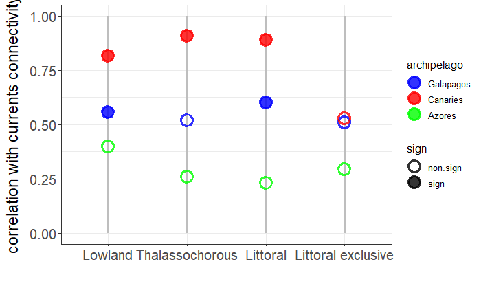

## Plot corr geographic distance

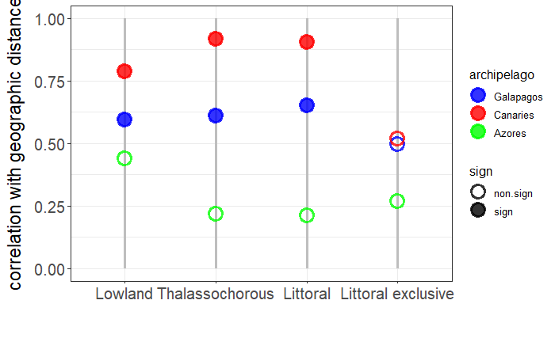

## Plot corr area

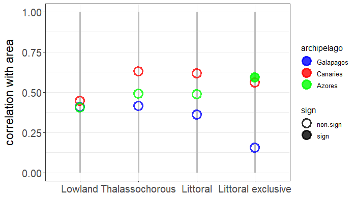

## Plot corr island age

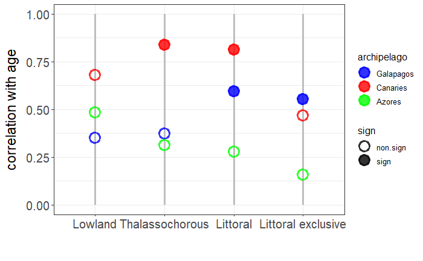

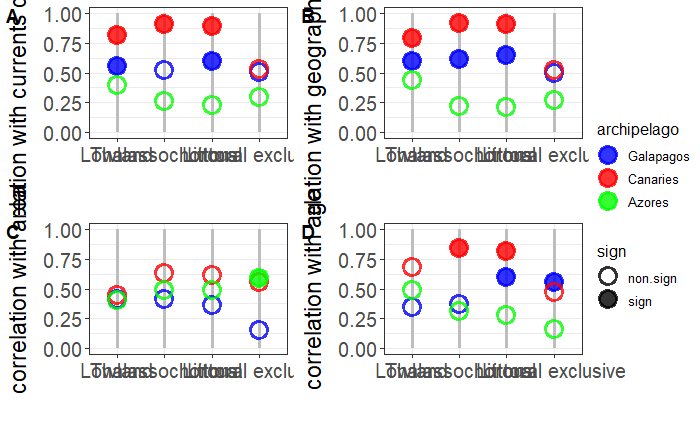

## Plot current connectivities

```r
png('archipelagos_currents_qplot.png', width=5000, height=1800, unit='px')

par(mfrow = c(1,3))
qgraph(dist_gal, layout='spring', vsize=12, border.color = "blue", esize =40, edge.color = "blue", curveAll = TRUE,minimum=0.0000000000)
qgraph(dist_can, layout='spring', vsize=12, border.color = "red", esize =40, edge.color = "red", curveAll = TRUE,minimum=0.0000000000)
qgraph(dist_az, layout='spring', vsize=12, border.color = "green", esize =40, edge.color = "green", curveAll = TRUE,minimum=0.0000000000)

dev.off()
```

# Correlation currents with geo, area, age

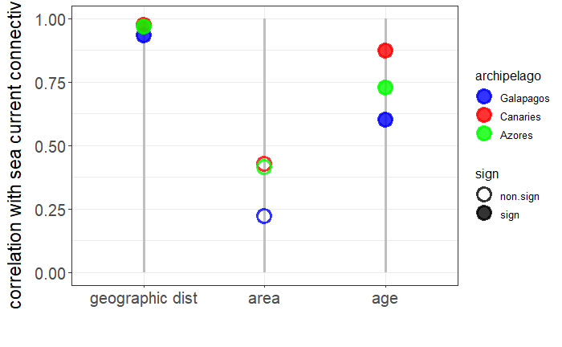

# % THA and Litt with centrality by currents:

Summing up the edge weights of the adjacent edges for each vertex.

## obtain degrees

```r
degrees_can
```

```
    El_Hierro Fuerteventura  Gran_Canaria     La_Gomera      La_Palma     Lanzarote      Tenerife
  0.005270675   3.912746938   0.005386074   0.008544794   0.005051735   3.912120064   0.007833564
```

### Open Data

```r
data_Galapagos <- read_csv("../Data/Data_Galapagos/data_galapagos.csv", col_names = FALSE, trim_ws = TRUE)
data_Canaries <- read_csv("../Data/Data_Canaries/data_canaries.csv", col_names = FALSE, trim_ws = TRUE)
data_Azores <- read_csv("../Data/Data_Azores/data_azores.csv", col_names = FALSE)

df_Galapagos <- as.data.frame(data_Galapagos)
df_Canaries <- as.data.frame(data_Canaries)
df_Azores <- as.data.frame(data_Azores)
```

## Smooth the data frame

```r
df_Galapagos[is.na(df_Galapagos)] <- 0
df_Galapagos <- unite(df_Galapagos, name_species, c(X2, X3), remove=FALSE)
df_Galapagos <- df_Galapagos %>% select(1,2,5:29)


df_Canaries[is.na(df_Canaries)] <- 0

df_Azores[is.na(df_Azores)] <- 0
```

## Galapagos

```r
# m = matrix

df_Galapagos$name_species <- gsub('Sesuvium_edmondstonei', 'Sesuvium_edmonstonei', df_Galapagos$name_species)
# Sesuvium edmondstonei has been probably misspelled by the data set. There is a specie called Sesuvium edmonstonei, correctly descrived by Wiggins & Porter (1971), native from Galapagos Islands (Title of vols. 1-6 (1791-1802) Transactions of the Linnean Society; for series 2 see Trans. Linn. Soc. London) (it can also be checked on http://powo.science.kew.org/taxon/235141-2). So we have changed the data set to correct the species spelling.

df_Galapagos$name_species <- gsub('Pycreus_polystachyos', 'Cyperus_polystachyos', df_Galapagos$name_species)
# The specie Pycreus polystachyos, found in our data, is a synonim of Cyperus polystachyos, found in Wiggins & Porter (1971). The taxonomical correct name is Cyperus polystachyos Rottb., Descr. Pl. Rar. 21 (1772), because it is ancient than Pycreus polystachyos P.Beauv., Fl. Oware 2: 48, t. 86 (1816). So we have changed Pycreus polystachyos to Cyperus polystachyos on our data.

df_Galapagos <- subset(df_Galapagos, df_Galapagos$X4 %in% c("1", "habitats<500m")) # We filter only lowland species
df_Galapagos <- subset(df_Galapagos, df_Galapagos$X5 %in% c("Id", "En", "EnQ", "Sub-Origin"))   # From lowland species, we filter only native (and endemic) species
```

```r
sf_perc_tha_gal
```

```
[1] 4.545455
```

##### Canaries

[figure not shown]

##### Azores

```r
SMR_perc_tha_can <- nrow(subset(df_Azores, df_Azores$X7 %in% c("0.33", "0.5", "1", "THA") & df_Azores$X10 %in% "1"))/nrow(df_Azores)*100
SMG_perc_tha_can <- nrow(subset(df_Azores, df_Azores$X7 %in% c("0.33", "0.5", "1", "THA") & df_Azores$X11 %in% "1"))/nrow(df_Azores)*100
TER_perc_tha_can <- nrow(subset(df_Azores, df_Azores$X7 %in% c("0.33", "0.5", "1", "THA") & df_Azores$X12 %in% "1"))/nrow(df_Azores)*100
GRA_perc_tha_can <- nrow(subset(df_Azores, df_Azores$X7 %in% c("0.33", "0.5", "1", "THA") & df_Azores$X13 %in% "1"))/nrow(df_Azores)*100
SJG_perc_tha_can <- nrow(subset(df_Azores, df_Azores$X7 %in% c("0.33", "0.5", "1", "THA") & df_Azores$X14 %in% "1"))/nrow(df_Azores)*100
PIC_perc_tha_can <- nrow(subset(df_Azores, df_Azores$X7 %in% c("0.33", "0.5", "1", "THA") & df_Azores$X15 %in% "1"))/nrow(df_Azores)*100
FAI_perc_tha_can <- nrow(subset(df_Azores, df_Azores$X7 %in% c("0.33", "0.5", "1", "THA") & df_Azores$X16 %in% "1"))/nrow(df_Azores)*100
FLO_perc_tha_can <- nrow(subset(df_Azores, df_Azores$X7 %in% c("0.33", "0.5", "1", "THA") & df_Azores$X17 %in% "1"))/nrow(df_Azores)*100
COR_perc_tha_can <- nrow(subset(df_Azores, df_Azores$X7 %in% c("0.33", "0.5", "1", "THA") & df_Azores$X18 %in% "1"))/nrow(df_Azores)*100


degrees_az
```

```
       COR        FAI        FLO        GRA        PIC        SJG        SMG        SMR        TER
0.22783947 1.15727647 0.22487897 0.17396550 1.25303012 0.40262897 0.06578318 0.04469614 0.13742203
```

```r
perc_tha_az <- c(COR_perc_tha_can, FAI_perc_tha_can, FLO_perc_tha_can, GRA_perc_tha_can, PIC_perc_tha_can, SJG_perc_tha_can, SMG_perc_tha_can, SMG_perc_tha_can, TER_perc_tha_can)
```

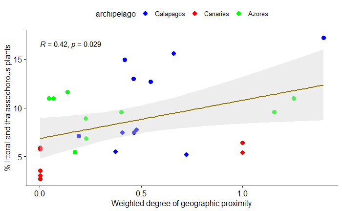